# Multivariate Geostatistics

gstlearn Team

## Preamble

In this preamble, we load the **gstlearn** library and clean the workspace.

```r
rm(list=ls())
library(gstlearn)
library(ggplot2)
library(ggpubr)

flagInternetAvailable=TRUE
```

```r
plot.setDefaultGeographic(dims=c(8,8))
```

We load two data bases:

- a data base `dat` containing point observations of two variables across Scotland: the elevation (`Elevation`) and the temperature (`January_temp`, then renamed as `Temperature`)
- a data base `target` containing a grid of points covering Scotland with a selection variable (`inshore`) selecting the points that are on land, and a variable (`Elevation`) giving the elevation at every point on land

```r
## Data points
fileNF = "Scotland_Temperatures.NF"
if(flagInternetAvailable){
  download.file(paste0("https://soft.minesparis.psl.eu/gstlearn/data/Scotland/",fileNF), fileNF)
}
dat = Db_createFromNF(fileNF)
### Rename the temperature variable
dat$setName("*temp", "Temperature")

## Target grid
fileNF = "Scotland_Elevations.NF"
if(flagInternetAvailable){
  download.file(paste0("https://soft.minesparis.psl.eu/gstlearn/data/Scotland/",fileNF), fileNF)
}
target = DbGrid_createFromNF(fileNF)
```

### Exploratory data analysis

The `target` data base a (grid) map of the elevation across Scotland.

```r
target
```

```
##
## Data Base Grid Characteristics
## ==============================
##
## Data Base Summary
## -----------------
## File is organized as a regular grid
## Space dimension              = 2
## Number of Columns            = 4
## Total number of samples      = 11097
## Number of active samples     = 3092
##
## Grid characteristics:
## ---------------------
## Origin :     65.000   535.000
## Mesh   :      4.938     4.963
## Number :         81       137
##
## Variables
## ---------
## Column = 0 - Name = Longitude - Locator = x1
## Column = 1 - Name = Latitude - Locator = x2
## Column = 2 - Name = Elevation - Locator = f1
## Column = 3 - Name = inshore - Locator = sel
```

Let us plot its content.

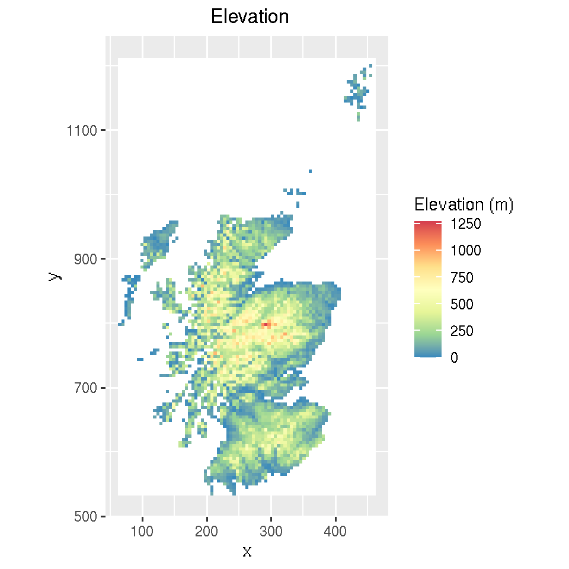

```r
ggDefaultGeographic() + plot(target, name_raster="Elevation",
                             show.legend.raster=TRUE,palette="Spectral",
                             legend.name.raster="Elevation (m)")
```

The `dat` data base contains 236 (point) samples of two variables across Scotland: elevation and temperature.

```r
dat
```

```
##
## Data Base Characteristics
## =========================
##
## Data Base Summary
## -----------------
## File is organized as a set of isolated points
## Space dimension              = 2
## Number of Columns            = 5
## Total number of samples      = 236
##
## Variables
## ---------
## Column = 0 - Name = rank - Locator = NA
## Column = 1 - Name = Longitude - Locator = x1
## Column = 2 - Name = Latitude - Locator = x2
## Column = 3 - Name = Elevation - Locator = NA
## Column = 4 - Name = Temperature - Locator = z1
```

For instance, let us count the number of observations of each variable using the `dbStatisticsPrint`.

```r
dbStatisticsPrint(dat, names = c("Elevation", "Temperature"),
                  opers=EStatOption_fromKeys(c("NUM")),
                  flagIso = FALSE, title="Number of observations", radix="")
```

```
##
## Number of observations
## ----------------------
##                 Number
## Elevation          236
## Temperature        151
```

Since the data base `dat` contains 236 samples, we can conclude that the `Elevation` variable is defined at every point, but not the `Temperature` variable. Similarly, we can compute the mean and the extreme values of each variable in the observation data base.

```r
dbStatisticsPrint(dat, names = c("Elevation", "Temperature"),
                  opers=EStatOption_fromKeys(c("MEAN","MINI","MAXI")),
                  flagIso = FALSE, title="Statistics of observations", radix="")
```

```
##
## Statistics of observations
## --------------------------
##                Minimum    Maximum       Mean
## Elevation        2.000    800.000    146.441
## Temperature      0.600      5.200      2.815
```

Finally, we compute the mean and the extreme values of the elevation in the target data base.

```r
dbStatisticsPrint(target, names = c("Elevation"),
                  opers=EStatOption_fromKeys(c("MEAN","MINI","MAXI")),
                  flagIso = FALSE, title="Statistics of target", radix="")
```

```
##
## Statistics of target
## --------------------
##              Minimum    Maximum       Mean
## Elevation      0.000   1270.000    241.152
```

We can then compute the filtered mean, minimum and maximum for the `Elevation` and `Temperature` variables as follows:

```r
dbStatisticsPrint(dat, names = c("Elevation", "Temperature"),
                  opers=EStatOption_fromKeys(c("MEAN","MINI","MAXI")),
                  flagIso = TRUE, title="Filtered statistics of observations", radix="")
```

```
##
## Filtered statistics of observations
## -----------------------------------
##                Minimum    Maximum       Mean
## Elevation        3.000    387.000     87.974
## Temperature      0.600      5.200      2.815
```

As explained above, the first row of the table contains contains the mean, the minimum and the maximum of the observations of the `Elevation` variable, over all the locations where both the `Elevation` na `Temperature` variables are defined (i.e. in our case, all the points where the temperature is defined). Hence, we see that the points where the temperature is observed are located at relatively low altitudes within the Scottish landscape.

To confirm that, we plot the points where the temperature is sampled on top of the elevation map of Scotland.

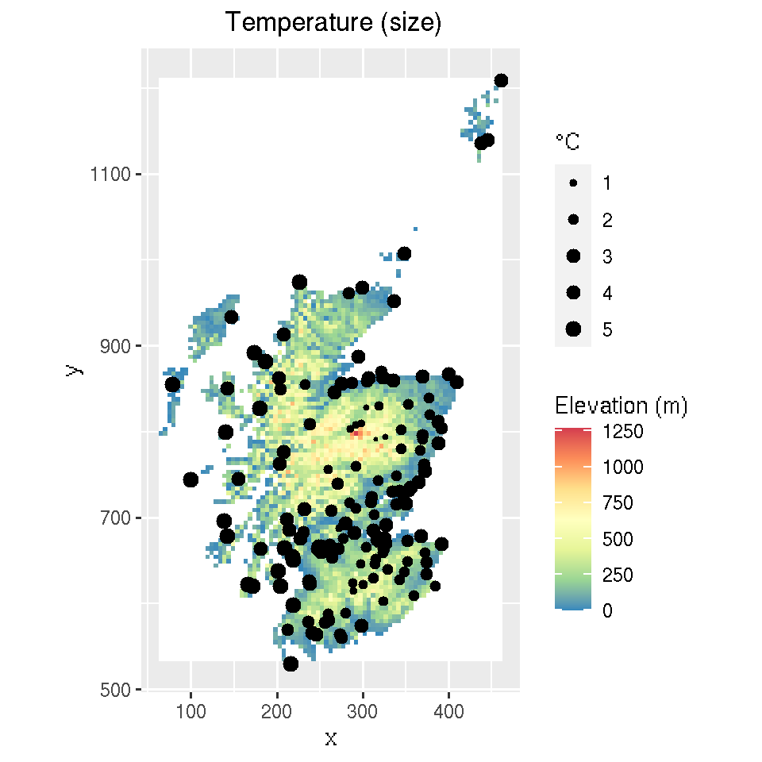

```r
p = ggDefaultGeographic()
p = p + plot.grid(target, name_raster="Elevation",
                  show.legend.raster=TRUE,palette="Spectral",
                  legend.name.raster="Elevation (m)")
p = p + plot.point(dat, name_size="Temperature",
                   sizmin = 0.5, sizmax = 3,
                   show.legend.size=TRUE,legend.name.size="°C")
ggPrint(p)
```

From observing this last plot, it seems like the bigger points (corresponding to high temperatures) are located where the elevation is smaller: this seems to hint (confirm?) that the temperature is negatively correlated with the elevation. To corroborate this, we plot a correlation plot between the two variables.

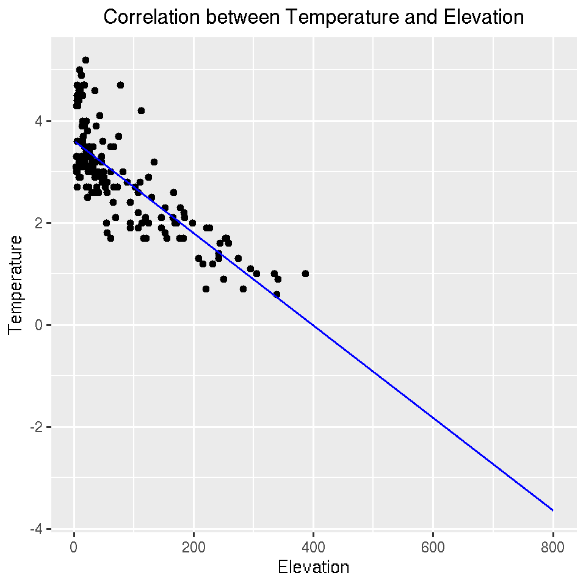

```r
p = ggplot()
p = p + plot.correlation(dat, namex="Elevation", namey="Temperature",
                     asPoint=TRUE, flagRegr=TRUE)
p = p + plot.decoration(title="Correlation between Temperature and Elevation")
ggPrint(p)
```

### Baseline univariate model

In this course, we will introduce four methods allowing to deal with multivariate data: Cokriging, Residual modeling, Models with polynomial trends and finally Models with an external drift. As a baseline, we will compare the results obtained with each model with the results obtained with a univariate model.

#### Model fitting

We start by computing an experimental directional variogram `vario_raw2dir` of the “raw” temperature observations, along two directions ($0^{\circ}\text{C}$ and $90^{\circ}\text{C}$).

```r
## Create experimental variogram on raw data
varioparam = VarioParam_createMultiple(ndir=2, npas=30, dpas=10)
vario_raw2dir = Vario(varioparam, dat)
err = vario_raw2dir$compute()
```

We then fit a model on the experimental variogram of raw temperature observations. Since we want to use ordinary kriging, we add a constant drift to the model before.

```r
fitmod_raw = Model()
err = fitmod_raw$fit(vario_raw2dir,
                    types=ECov_fromKeys(c("NUGGET","EXPONENTIAL","CUBIC","LINEAR")))
fitmod_raw$setDriftIRF(0,0)
```

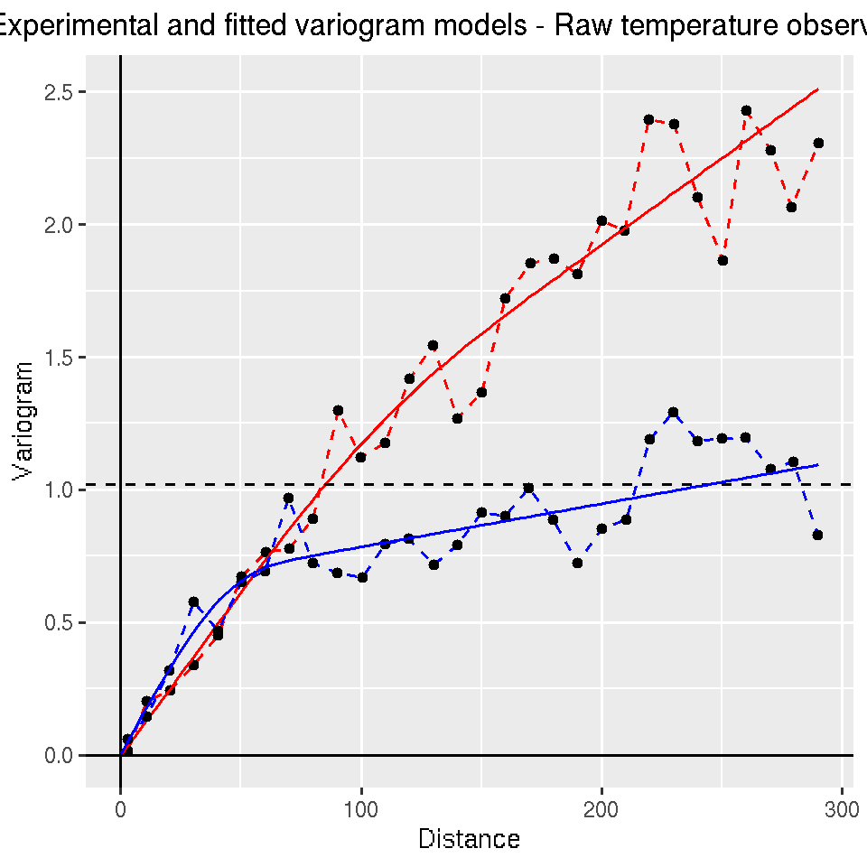

```r
p = ggplot()
p = p + plot.varmod(vario_raw2dir, fitmod_raw)
p = p + plot.decoration(title="Experimental and fitted variogram models - Raw temperature observations")
ggPrint(p)
```

#### Ordinary kriging

We create a “neighborhood” object specifying a unique neighborhood, which we will use throughout the course.

```r
uniqueNeigh = NeighUnique_create()
```

We now perform an ordinary kriging prediction of the temperature on the `target` grid using the model fitted on the raw observations, and compute statistics on the predicted values.

```r
err = kriging(dbin=dat, dbout=target, model=fitmod_raw,
              neigh=uniqueNeigh,
              namconv=NamingConvention_create(prefix="OK"))
```

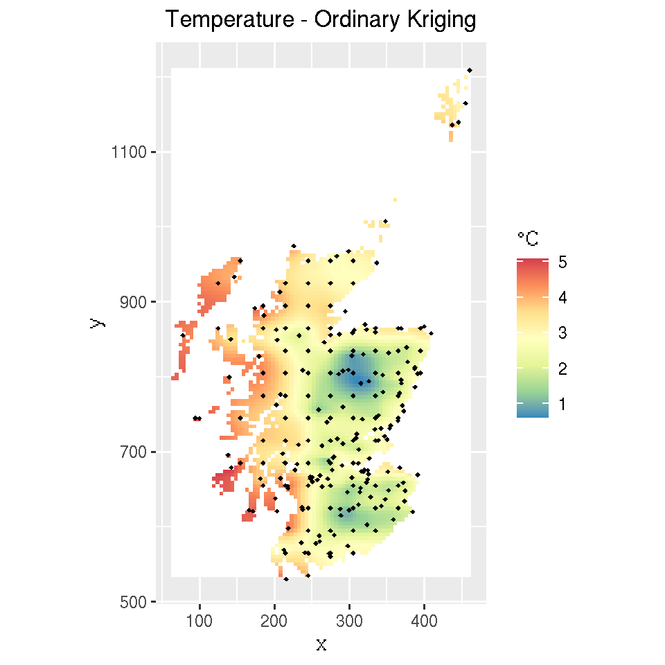

```r
## Plot
p = ggDefaultGeographic()
p = p + plot.grid(target,name_raster = "OK*estim",
                  show.legend.raster = TRUE, palette="Spectral",legend.name.raster="°C")
p = p + plot.point(dat,flagCst = T,pch=18,cex=1)
p = p + plot.decoration(title="Temperature - Ordinary Kriging")
ggPrint(p)
```

```r
opers=EStatOption_fromKeys(c("NUM","MINI","MAXI","MEAN","STDV"))
dbStatisticsPrint(target, names=(c("OK.T*")), opers=opers,
                  title="Statistics on the Ordinary Kriging:", radix="")
```

```
##
## Statistics on the Ordinary Kriging:
## -----------------------------------
##                          Number    Minimum    Maximum       Mean   St. Dev.
## OK.Temperature.estim       3092      0.604      5.083      2.834      0.954
## OK.Temperature.stdev       3092      0.077      0.992      0.492      0.145
```

#### Cross-validation

We perform a cross-validation of the fitted model using Ordinary Kriging, and calculate the Mean Squared cross-validation and standardized errors.

```r
## Compute cross-validation
err = xvalid(dat, model=fitmod_raw,
             neigh=uniqueNeigh,
             namconv=NamingConvention_create(prefix="CV_OK",flag_locator=FALSE))
```

```r
mse=mean(dat$getColumn("CV_OK*esterr*")^2,na.rm=TRUE)
cat(c("Mean squared cross-validation error:",
        round(mse,3),
      "\n"))
```

```
## Mean squared cross-validation error: 0.254
```

```r
mse=mean(dat$getColumn("CV_OK*stderr*")^2,na.rm=TRUE)
cat(c("Mean squared standardized error:",
        round(mse,3),
      "\n"))
```

```
## Mean squared standardized error: 1.117
```

## Multivariate Models and Cokriging

To create and work with multivariate models, we simply need to work with `Db` objects containing more than one variable with a `z` locator. All the variables with a `z` locator will be considered as part of the multivariate model. Then, the same commands as in the univariate case can be used to create and fit experimental variograms, and to perform (co)kriging predictions.

Let us illustrate our point with our running example. We would like now to consider a bivariate model of the temperature and the elevation. To do so, we simply allocate, in the observation data base `dat`, a `z` locator to both variables using the `setLocators` method.

```r
dat$setLocators(names=c("Temperature", "Elevation"),
                locatorType=ELoc_Z())
```

```r
dat
```

```
##
## Data Base Characteristics
## =========================
##
## Data Base Summary
## -----------------
## File is organized as a set of isolated points
## Space dimension              = 2
## Number of Columns            = 7
## Total number of samples      = 236
##
## Variables
## ---------
## Column = 0 - Name = rank - Locator = NA
## Column = 1 - Name = Longitude - Locator = x1
## Column = 2 - Name = Latitude - Locator = x2
## Column = 3 - Name = Elevation - Locator = z2
## Column = 4 - Name = Temperature - Locator = z1
## Column = 5 - Name = CV_OK.Temperature.esterr - Locator = NA
## Column = 6 - Name = CV_OK.Temperature.stderr - Locator = NA
```

### Fitting a bivariate model

To create experimental (directional) variograms and cross-variograms, we use the same commands as in the univariate case: since the data base `dat` now contains two variables with a `z` locator, the `compute` method automatically computes both variograms and cross-variograms for these variables.

```r
varioexp2var = Vario_create(varioparam, dat)
err = varioexp2var$compute()
```

We can then plot the experimental variograms and cross-variograms with a simple command: the plot in the i-th row and j-th column corresponds to the cross-variogram between the variables with locators `zi` and `zj` (hence the diagonal plots correspond to the variograms of each variable).

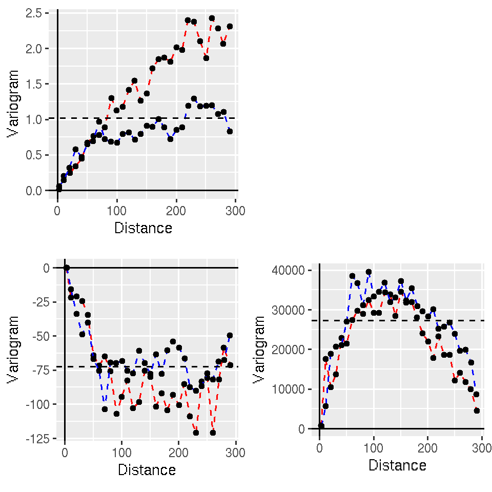

```r
multi.varmod(varioexp2var)
```

To fit a model on the experimental variograms and cross-variograms, we use the same commands as in the univariate case.

```r
fitmod2var = Model()
err = fitmod2var$fit(varioexp2var,
                     types=ECov_fromKeys(c("NUGGET","EXPONENTIAL","CUBIC","LINEAR")))
fitmod2var$setDriftIRF(0,0)
```

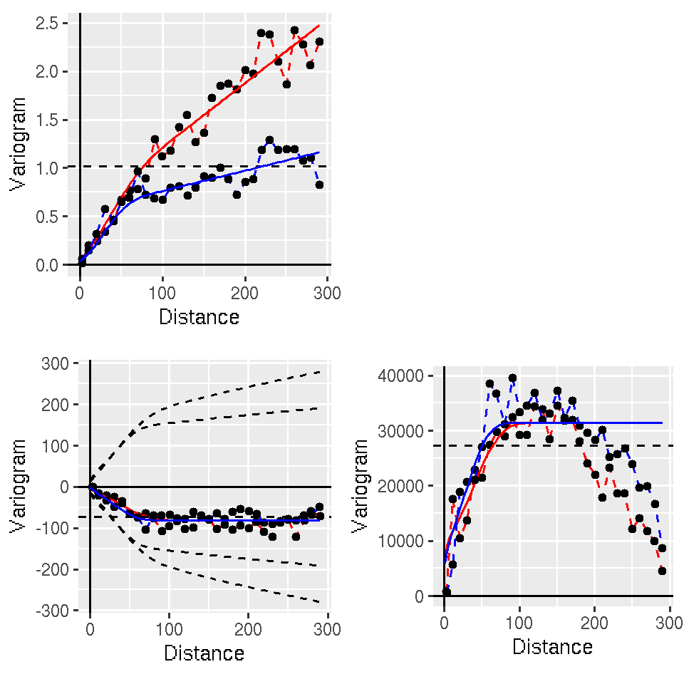

```r
multi.varmod(varioexp2var, fitmod2var)
```

### Cokriging predictions

To compute predictions by (simple) cokriging on the grid, we use the same syntax as in univariate case: a predictor for each variable in the multivariate model is produced. (Note: we revert back to a unique neighborhood to compare with the predictors previously introduced).

```r
err = kriging(dbin=dat, dbout=target, model=fitmod2var,
              neigh=uniqueNeigh,
              namconv=NamingConvention_create(prefix="COK"))
```

We can then represent the cokriging predictor for the temperature.

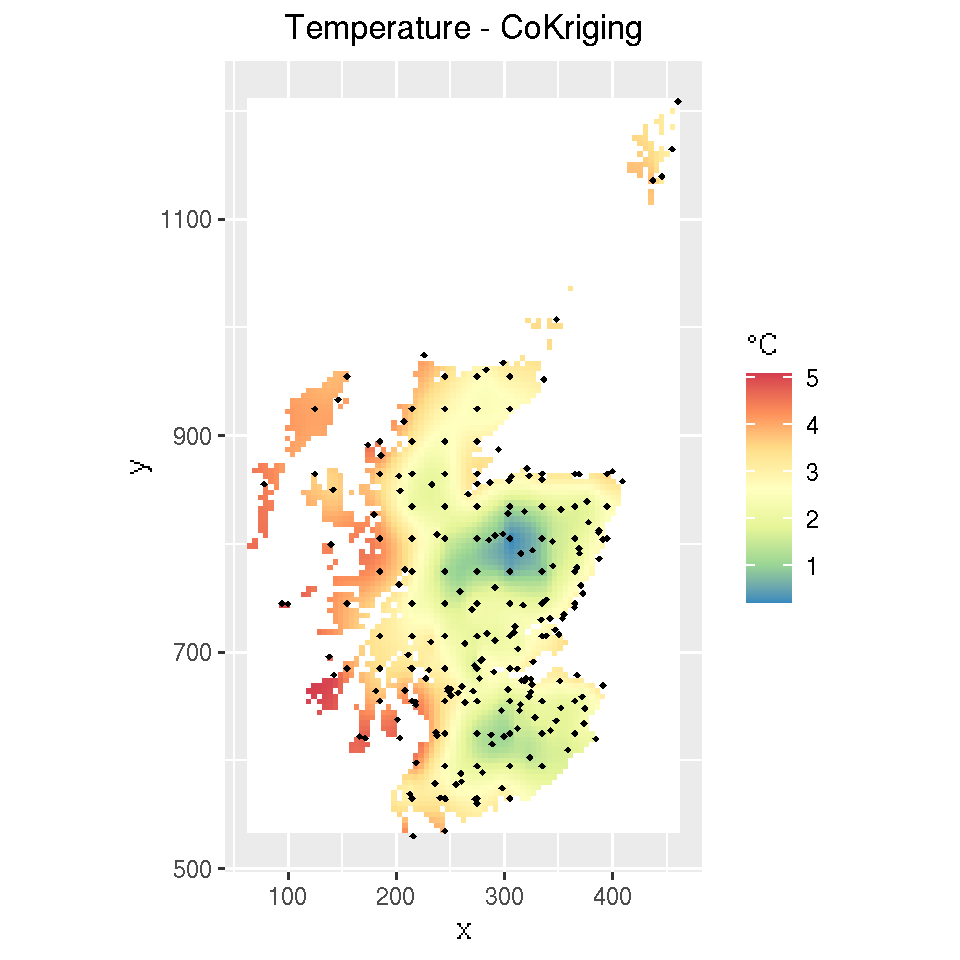

```r
p = ggDefaultGeographic()
p = p + plot.grid(target,name_raster = "COK.Temp*estim",
                  show.legend.raster = TRUE,
                  palette="Spectral",legend.name.raster="°C")
p = p + plot.point(dat,flagCst = T,pch=18,cex=1)
p = p + plot.decoration(title="Temperature - CoKriging")
ggPrint(p)
```

For this predictor, we get the following statistics:

```r
opers=EStatOption_fromKeys(c("NUM","MINI","MAXI","MEAN","STDV"))
dbStatisticsPrint(target, names=(c("COK.T*")), opers=opers,
                  title="Statistics on the CoKriging predictions",
                  radix="")
```

```
##
## Statistics on the CoKriging predictions
## ---------------------------------------
##                           Number    Minimum    Maximum       Mean   St. Dev.
## COK.Temperature.estim       3092      0.200      5.094      2.671      0.970
## COK.Temperature.stdev       3092      0.231      0.948      0.448      0.109
```

Finally, we compare the cokriging predictor to the ordinary kriging predictor.

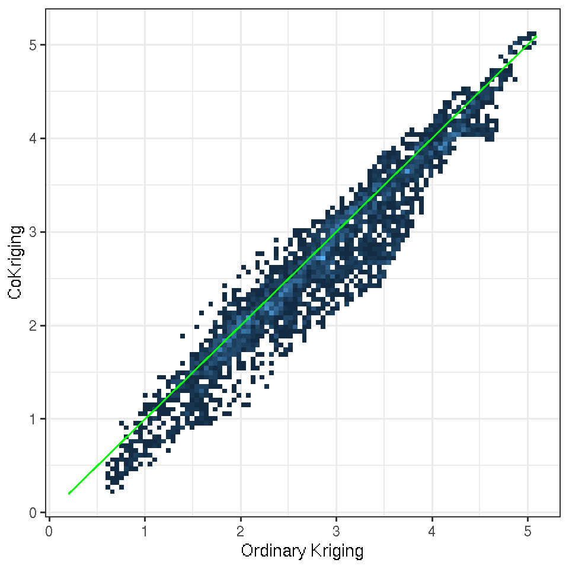

```r
p = ggplot()
p = p + plot.correlation(target, namex="OK.T*estim", namey="COK.T*estim",
                     flagBiss=TRUE, bins=100)
p = p + plot.decoration(xlab="Ordinary Kriging",ylab="CoKriging")
ggPrint(p)
```

```r
opers=EStatOption_fromKeys(c("NUM","MINI","MAXI","MEAN","STDV"))
dbStatisticsPrint(target, names=c("OK.T*estim", "COK.T*estim"), opers=opers,
                  title="Comparison between Ordinary and Universal kriging predictions",
                  radix="")
```

```
##
## Comparison between Ordinary and Universal kriging predictions
## -------------------------------------------------------------
##                           Number    Minimum    Maximum       Mean   St. Dev.
## OK.Temperature.estim        3092      0.604      5.083      2.834      0.954
## COK.Temperature.estim       3092      0.200      5.094      2.671      0.970
```

### Cross-validation

Since cokriging can be time-consuming in Unique Neighborhood, we create a small moving neighborhood for demonstration.

```r
movingNeigh = NeighMoving_create(radius = 1000, nmaxi = 10)
```

To perform a cross-validation of the bivariate model using co-kriging, we use the same commands as in the univariate case. Then cross-validation errors are computed for each variable of the multivariate model (hence for both the Temperature and the Elevation in our case).

```r
err = xvalid(dat, model=fitmod2var,
             neigh=movingNeigh,
             namconv=NamingConvention_create(prefix="CV_COK",flag_locator=FALSE))
```

We obtain the following Mean Squared Errors for the temperature.

```r
mse=mean(dat$getColumn("CV_COK.Temperature.esterr*")^2,na.rm=TRUE)
cat(c("Mean squared cross-validation error:",
        round(mse,3),
      "\n"))
```

```
## Mean squared cross-validation error: 0.279
```

```r
mse=mean(dat$getColumn("CV_COK.Temperature.stderr*")^2,na.rm=TRUE)
cat(c("Mean squared standardized error:",
        round(mse,3),
      "\n"))
```

```
## Mean squared standardized error: 1.227
```

We obtain the following Mean Squared Errors for the elevation.

```r
mse=mean(dat$getColumn("CV_COK.Elevation.esterr*")^2,na.rm=TRUE)
cat(c("Mean squared cross-validation error:",
        round(mse,3),
      "\n"))
```

```
## Mean squared cross-validation error: 17849.434
```

```r
mse=mean(dat$getColumn("CV_COK.Elevation.stderr*")^2,na.rm=TRUE)
cat(c("Mean squared standardized error:",
        round(mse,3),
      "\n"))
```

```
## Mean squared standardized error: 1.206
```

## Working with residuals

In this section, we assume that the variable of interest $Z$ is modeled (at each location $x$) as
$$Z(x)
= b+a Y(x) + \varepsilon(x)$$
where $Y$ is an auxiliary variable known at every location, $a$ and $b$ are some (unknown) regression coefficients, and $\varepsilon$ denotes stationary residuals. Our goal will be to model and work directly with the residuals $\varepsilon$ (since they are the one who are assumed to be stationary).

### Computing and fitting the residuals

In our running example, the variable of interest $Z$ will be the temperature, and the auxiliary variable $Y$ will be the elevation. In the observation data base, we start by assigning the locator `z` to the `Temperature` variable (this is our variable of interest), and ensure that it is the only variable with a `z` locator.

```r
## Set `z` locator to temperature
err = dat$setLocator("Temperature",ELoc_Z(),cleanSameLocator=TRUE)
```

To compute the coefficients $a$ and $b$ of the linear regression between the temperature and the elevation, we can use the `regression` function. We specify the name of response variable (argument `name0`) and the names of the auxiliary variables (argument `names`), and set the argument `mode=0` to specify that we would like to compute a regression defined from the variables with the specified names. We also set the argument `flagCst=TRUE` to specify that we are looking for an affine regression model between the variables (i.e. that includes the bias coefficient `b`).

```r
## Fit regression model
regr = regression(dat, name0="Temperature", names="Elevation", mode=0,
                  flagCst=TRUE)

## Extract coefficients
b = regr$coeffs[1]
a = regr$coeffs[2]

cat(c("Coefficents : b=",round(b,3),"; a=",round(a,5)))
```

```
## Coefficents : b= 3.612 ; a= -0.00906
```

From these regression coefficients obtained above, we can then compute the residuals explicitly as $\varepsilon(x)=Z(x) - (b+a Y(x) )$. An alternative method consists in using the `dbRegression` function: this functions fits a regression model, computes the residuals and add them directly on the data base containing the data. The `dbRegression` function is called in a similar way as the `regression` function.

In the next example, we compute the residuals of the linear regression between the temperature and the elevation and add them to the observation data base (with a name starting with “RegRes”and without changing the locators in the data base).

```r
err = dbRegression(dat, name0="Temperature", namaux="Elevation", mode=0,
                   flagCst = TRUE,
                   namconv = NamingConvention_create(prefix="RegRes",flag_locator=FALSE))
```

We then compute some statistics about these residuals.

```r
opers=EStatOption_fromKeys(c("NUM","MINI","MAXI","MEAN","STDV"))
dbStatisticsPrint(dat, names=c("RegRes*"), opers=opers,
                  title="Statistics on the residuals",
                  radix="")
```

```
##
## Statistics on the residuals
## ---------------------------
##                        Number    Minimum    Maximum       Mean   St. Dev.
## RegRes.Temperature        151     -1.359      1.795      0.000      0.603
```

Finally we plot a correlation plot between the residuals and the regressor variable (i.e. the elevation).

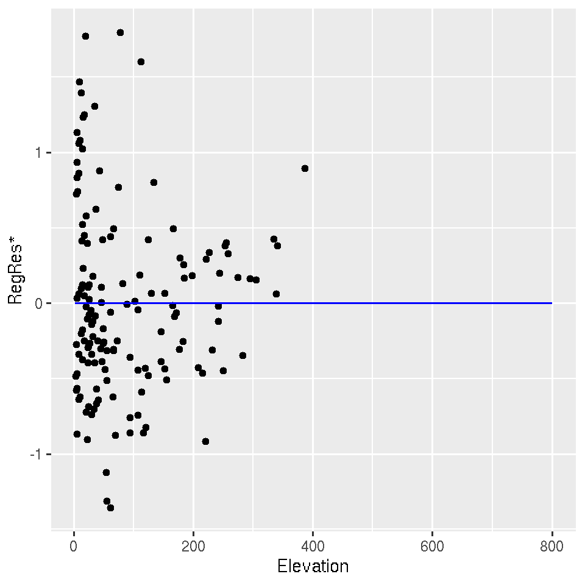

```r
ggplot() + plot.correlation(dat,namex="Elevation",namey="RegRes*",
                            flagRegr=TRUE,asPoint=TRUE)
```

Now that the residuals are explicitly computed and available in the observation data base, we can proceed to work with them as with any other variable.

We start by setting their locator to `z` to specify that they are now our variable of interest within the data base (instead of the raw temperature observations).

```r
dat$setLocator("RegRes*",ELoc_Z(), cleanSameLocator=TRUE)
```

Then we can compute an experimental variogram for the residuals and fit a model on them.

```r
## Compute experimental variogram
varioexpR = Vario(varioparam, dat)
err = varioexpR$compute()

## Fit model
fitmodR = Model()
err = fitmodR$fit(varioexpR,
                  types=ECov_fromKeys(c("NUGGET","SPHERICAL","LINEAR")))
fitmodR$setDriftIRF(0,0)
```

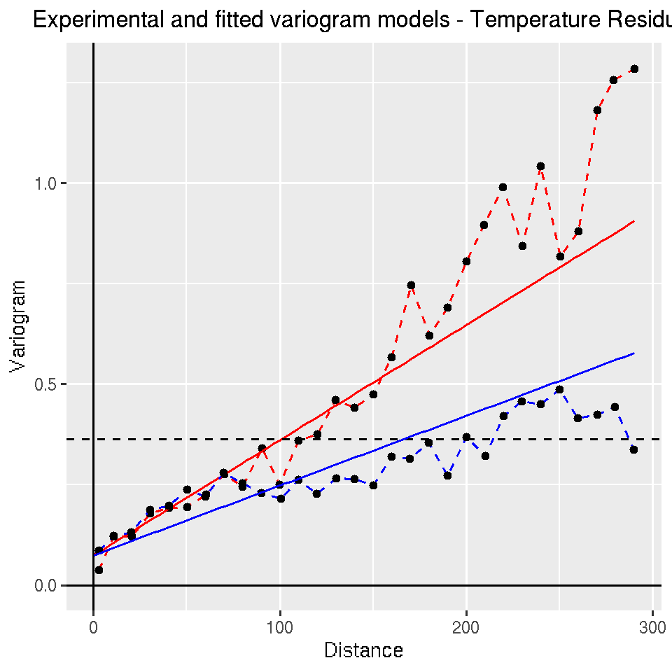

```r
p = ggplot()
p = p + plot.varmod(varioexpR, fitmodR)
p = p + plot.decoration(title="Experimental and fitted variogram models - Temperature Residual")
ggPrint(p)
```

### Ordinary kriging of the residuals

Finally, we can compute an ordinary kriging prediction of the residuals and plot the results.

```r
err = kriging(dbin=dat, dbout=target, model=fitmodR,
              neigh=uniqueNeigh,
              namconv=NamingConvention_create(prefix="ROK"))
```

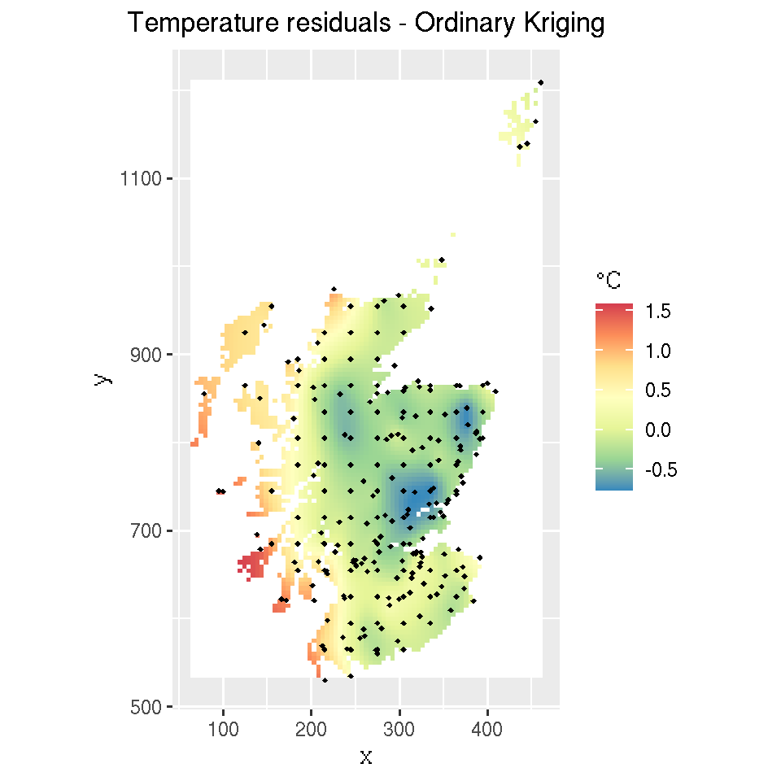

```r
p = ggDefaultGeographic()
p = p + plot.grid(target,name_raster = "ROK*estim",
                  show.legend.raster = TRUE, palette="Spectral",legend.name.raster="°C")
p = p + plot.point(dat,flagCst = T,pch=18,cex=1)
p = p + plot.decoration(title="Temperature residuals - Ordinary Kriging")
ggPrint(p)
```

Now that the residuals $\varepsilon^{OK}$ are predicted everywhere on the grid (by ordinary kriging), we can compute a predictor $Z^*$ for the temperature by simply adding the back the linear regression part of the model, i.e. by computing

$$Z^{\star}(x) = b + a Y(x) + \varepsilon^{OK}(x)$$
We can compute this predictor by directly manipulating the variables of the `target` data base.

```r
## Compute temperature predictor
ROK_estim =  b + a * target["Elevation"] + target["ROK*estim"]

## Add it to data base
uid = target$addColumns(ROK_estim,"KR.Temperature.estim")
```

Let us plot the resulting temperature predictions.

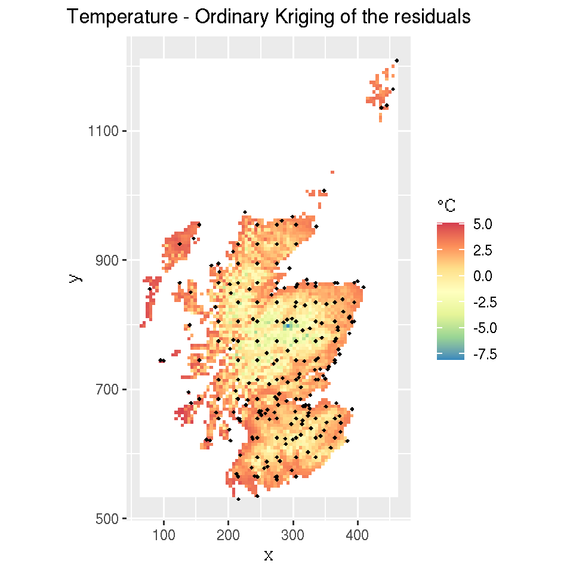

```r
p = ggDefaultGeographic()
p = p + plot.grid(target,name_raster = "KR.T*estim",
                  show.legend.raster = TRUE, palette="Spectral",legend.name.raster="°C")
p = p + plot.point(dat,flagCst = T,pch=18,cex=1)
p = p + plot.decoration(title="Temperature - Ordinary Kriging of the residuals")
ggPrint(p)
```

Finally, we compare the predictor obtained by kriging of the residuals to the ordinary kriging predictor.

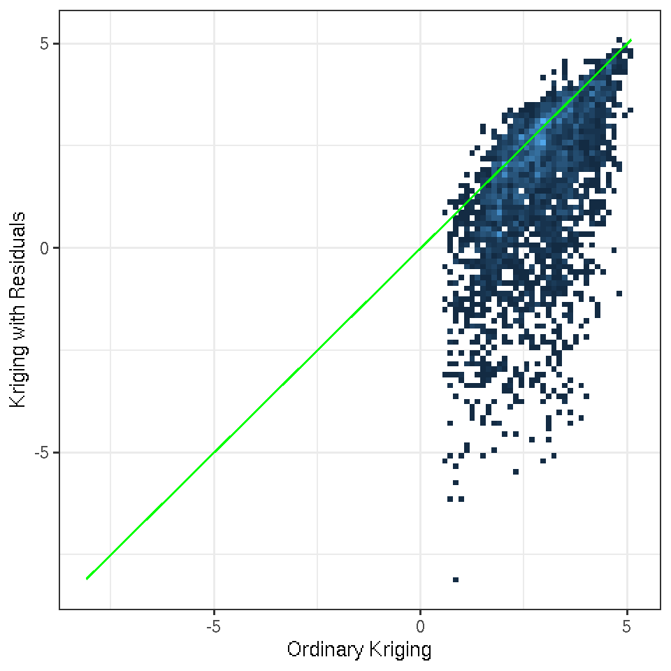

```r
p = ggplot()
p = p + plot.correlation(target, namex="OK.T*estim", namey="KR.T*estim",
                         flagBiss=TRUE, bins=100)
p = p + plot.decoration(xlab="Ordinary Kriging",ylab="Kriging with Residuals")
ggPrint(p)
```

```r
opers=EStatOption_fromKeys(c("NUM","MINI","MAXI","MEAN","STDV"))
dbStatisticsPrint(target, names=c("OK.T*estim", "KR.T*estim"), opers=opers,
                  title="Comparison between Ordinary and Residual kriging predictions",
                  radix="")
```

```
##
## Comparison between Ordinary and Residual kriging predictions
## ------------------------------------------------------------
##                          Number    Minimum    Maximum       Mean   St. Dev.
## OK.Temperature.estim       3092      0.604      5.083      2.834      0.954
## KR.Temperature.estim       3092     -8.097      5.108      1.445      1.906
```

## Models with auxiliary variables

### Models with polynomial trends (intrinsic model)

In this subsection, we move to a model for the data where the temperature $Z$ at each location is considered to have a polynomial trend, i.e. we can write, for any location $x$,
$$Z(x) = P(x) + \varepsilon(x)$$
where $P$ is a polynomial function of the coordinates $x$, and $\varepsilon$ denotes stationary residuals. This model can also be referred to as an intrinsic model.

#### Fitting a model with a polynomial trend

As before, in the observation data base, we start by assigning the locator `z` to the `Temperature` variable (this is our variable of interest), and ensure that it is the only variable with a `z` locator.

```r
err = dat$setLocator("Temperature",ELoc_Z(),cleanSameLocator=TRUE)
```

It is possible to directly compute the experimental variogram of the residuals $\varepsilon$. To do so, we start by creating a `Model` object in which we specify, through the `setDriftIRF` method, the (maximal) degree of the polynomial trend `P`.

Then, computing the (possibly directional) experimental variogram of the residuals is done in the same way as for an “ordinary” experimental variogram, the only difference being that we now add in the `compute` method of the `Vario` class, the `Model` object specifying the polynomial trend (argument `model`). Then, the methods takes care of filtering out of the observations a polynomial trend of the specified degree, before computing the experimental variogram on the remaining residuals.

For instance, if we want to compute an experimental variogram of the residuals from a model with a linear trend (polynomial of degree 1), then we can run the following commands.

```r
## Create model and set polynomial drift of degree 1
polDriftModel = Model_create()
err = polDriftModel$setDriftIRF(order=1)

## Compute variogram of residuals
vario_res2dir = Vario(varioparam, dat)
err = vario_res2dir$compute(model=polDriftModel)
```

When plotting the experimental variograms, we notice that in one of the directions, the variogram does not reach a plateau. This suggests that a non-stationary model could be more suited for the analysis of these temperature observations.

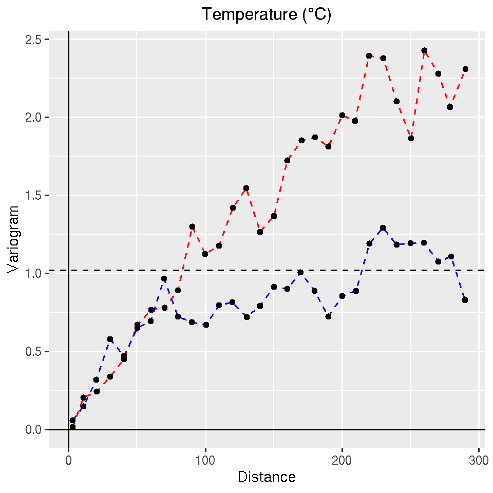

```r
p = ggplot()
p = p + plot.varmod(vario_raw2dir)
p = p + plot.decoration(title="Temperature (°C)")
ggPrint(p)
```

Then, we can now fit that a model on the experimental variorgram using the `fit` method in the usual way.

```r
err = polDriftModel$fit(vario_res2dir,
                        types=ECov_fromKeys(c("NUGGET","EXPONENTIAL","CUBIC")))
```

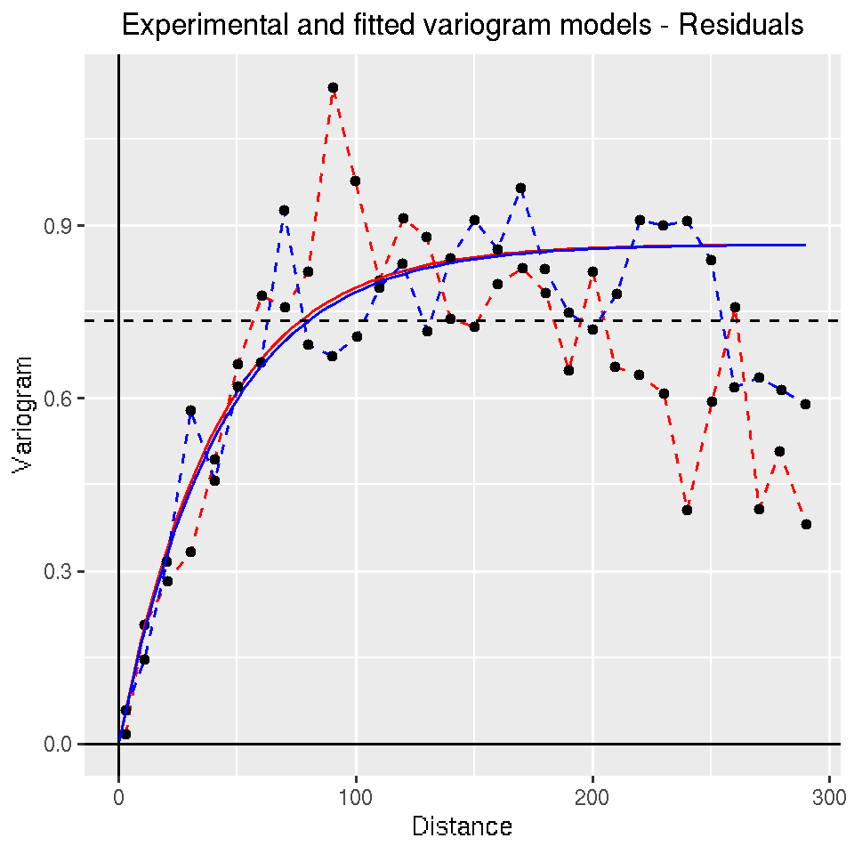

```r
p = ggplot()
p = p + plot.varmod(vario_res2dir, polDriftModel)
p = p + plot.decoration(title="Experimental and fitted variogram models - Residuals")
ggPrint(p)
```

Finally, note that it is possible to compute the coefficients of the polynomial trend from the intrinsic model defined above, using the function `regression`. This function allows to perform linear regressions on variables defined in a data base.

For instance, to fit a linear trend on the temperature observations in the `dat` data base, we specify the name of response variable (argument `name0`) and the drift model (argument `model`), and set the argument `mode=2` to specify that we would like to compute a regression defined from a drift model. Finally we set the argument `verbose=TRUE` to print the results.

```r
regResults = regression(dat, name0="Temperature",  model=polDriftModel,
                        mode=2, verbose=TRUE)
```

```
##
## Linear Regression
## -----------------
## - Calculated on 151 active values
## - Explanatory Variable #1 = 3.521360
## - Explanatory Variable #2 = -0.007466
## - Explanatory Variable #3 = 0.001978
## - Initial variance        = 1.019788
## - Variance of residuals   = 0.735557
```

Note: The regression results are stored in an object. We can access the coefficients through the slot `coeffs`, the initial variance of the data through the slot `variance` and the variance of the residuals through the slot `varres`.

#### Universal kriging

To work with universal kriging, it suffices to call the `kriging` (to compute predictions) or `xvalid` (to perform cross-validation) with a `Model` object that includes polynomial drift functions. In particular, we do not need to explictly compute any type of residuals.

Let’s compute an universal kriging prediction of the temperature on the `target` grid using the model fitted on the residuals.

```r
err = kriging(dbin=dat, dbout=target, model=polDriftModel,
              neigh=uniqueNeigh,
              namconv=NamingConvention_create(prefix="UK"))
```

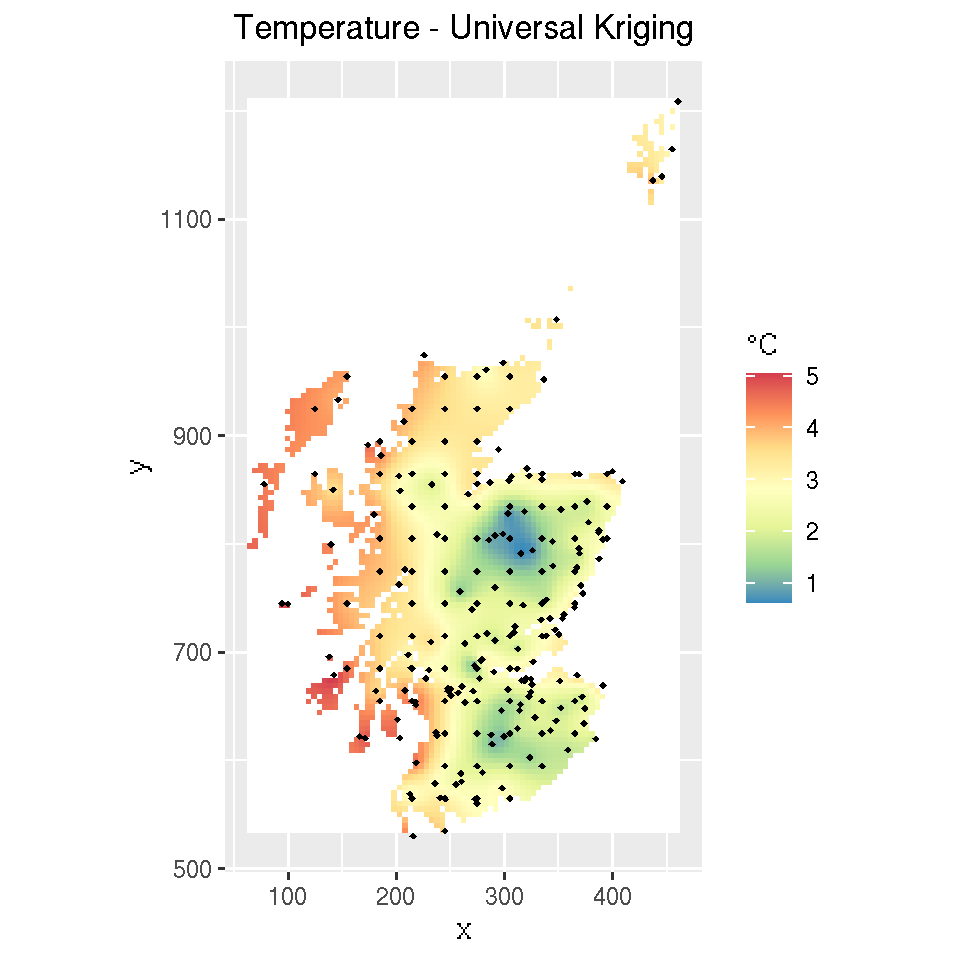

```r
## Plot
p = ggDefaultGeographic()
p = p + plot.grid(target,name_raster = "UK*estim",
                  show.legend.raster = TRUE,
                  palette="Spectral",legend.name.raster="°C")
p = p + plot.point(dat,flagCst = T,pch=18,cex=1)
p = p + plot.decoration(title="Temperature - Universal Kriging")
ggPrint(p)
```

We compute some statistics on the predicted values.

```r
opers=EStatOption_fromKeys(c("NUM","MINI","MAXI","MEAN","STDV"))
dbStatisticsPrint(target, names=c("UK.T*"), opers=opers,
                  title="Statistics on the Universal Kriging:", radix="")
```

```
##
## Statistics on the Universal Kriging:
## ------------------------------------
##                          Number    Minimum    Maximum       Mean   St. Dev.
## UK.Temperature.estim       3092      0.613      5.051      2.841      0.923
## UK.Temperature.stdev       3092      0.083      0.919      0.555      0.138
```

Let us compare the predictions obtained when considering a polynomial trend in the model, with the ordinary kriging predictor based on the “raw” temperature observations. We plot a correlation plot between the ordinary and universal kriging predictions, compare their respective statistics.

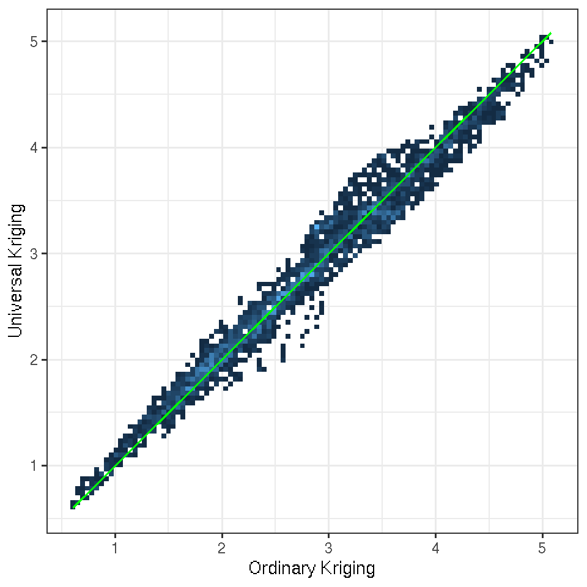

```r
p = ggplot()
p = p + plot.correlation(target, namex="OK*estim", namey="UK*estim",
                         flagBiss=TRUE, bins=100)
p = p + plot.decoration(xlab="Ordinary Kriging",ylab="Universal Kriging")
ggPrint(p)
```

```r
opers=EStatOption_fromKeys(c("NUM","MINI","MAXI","MEAN","STDV"))
dbStatisticsPrint(target, names=c("OK.T*estim", "UK.T*estim"), opers=opers,
                  title="Comparison between Ordinary and Universal kriging predictions:",
                  radix="")
```

```
##
## Comparison between Ordinary and Universal kriging predictions:
## --------------------------------------------------------------
##                          Number    Minimum    Maximum       Mean   St. Dev.
## OK.Temperature.estim       3092      0.604      5.083      2.834      0.954
## UK.Temperature.estim       3092      0.613      5.051      2.841      0.923
```

#### Cross-validation

To perform cross-validation using Universal Kriging, we simply call the `xvalid` function with the model we fitted on the residuals.

```r
err = xvalid(dat, model=polDriftModel,
             neigh=uniqueNeigh,
             namconv=NamingConvention_create(prefix="CV_UK",flag_locator=FALSE))
```

The Mean Squared cross-validation and standardized errors of the universal kriging predictor are:

```r
mse=mean(dat$getColumn("CV_UK*esterr*")^2,na.rm=TRUE)
cat(c("Mean squared cross-validation error:",
      round(mse,3),
      "\n"))
```

```
## Mean squared cross-validation error: 0.251
```

```r
mse=mean(dat$getColumn("CV_UK*stderr*")^2,na.rm=TRUE)
cat(c("Mean squared standardized error:",
      round(mse,3),
      "\n"))
```

```
## Mean squared standardized error: 0.855
```

### Models with External Drifts

In this last section, we investigate how to specify and work with external drifts when modeling data. In a data base, external drifts are identified by allocating a locator `f` to them in the data bases.

For instance, circling back to our running example, let us assume that we would like to model the temperature with an external drift given by the elevation. Then, in the observation data base, we simply need to allocate a `z` locator to the temperature variable and a `f` locator to the elevation variable using the `setLocator` method. Note: we use the flag `cleanSameLocator=TRUE` to make sure that only the variable we specify carries the locator.

```r
## Set `z` locator to temperature
err = dat$setLocator("Temperature",ELoc_Z(),
                     cleanSameLocator=TRUE)

## Set `f` locator to elevation
err = dat$setLocator("Elevation",ELoc_F(),
                     cleanSameLocator=TRUE)
```

Then, defining and fitting the models on the one hand, and performing kriging predictions on the other hand, is done using the same approach as the one described earlier for models with a polynomial trend.

#### Fitting a model with external drifts

To create experimental (directional) variograms of the residuals from a model with external drift, we use the same approach as the one described for modeling data with polynomial trends.

First, we create a `Model` object where we specify that we deal with external drifts. This is once again done through the `setDriftIRF` function where we specify:

- the number of external drift variables (argument `nfex`): this is the number of variables with a `f` locator the we want to work with
- the maximal degree of the polynomial trend in the data (argument `order`): setting `order=0` allows to add a constant drift to the model, and setting `order` to a value $n$ allows to add all the monomial functions of the coordinates of order up to $n$ as external drifts (on top of the `nfex` external drift variables)

Circling back to our example, we create a model with a single external drift (the elevation), and add a constant drift (that basically acts like a bias term).

```r
EDmodel = Model_create()
err = EDmodel$setDriftIRF(order=0,nfex=1)
```

Then, to compute the experimental variogram, we use the same commands as in the case of polynomial trends: we create a `Vario` object from the data base containing the data, and call the `compute` method with the model we just created. The experimental variogram is computed on the residuals obtained after “filtering out” the (linear) effect of the drift variables (and possibly of a polynomial trend if specified in the model).

```r
varioKED = Vario(varioparam, dat)
err = varioKED$compute(model=EDmodel)
```

As a reference, we plot the experimental variograms computed on the raw temperature data (dotted lines) and on the residuals from the model with external drift (dashed line).

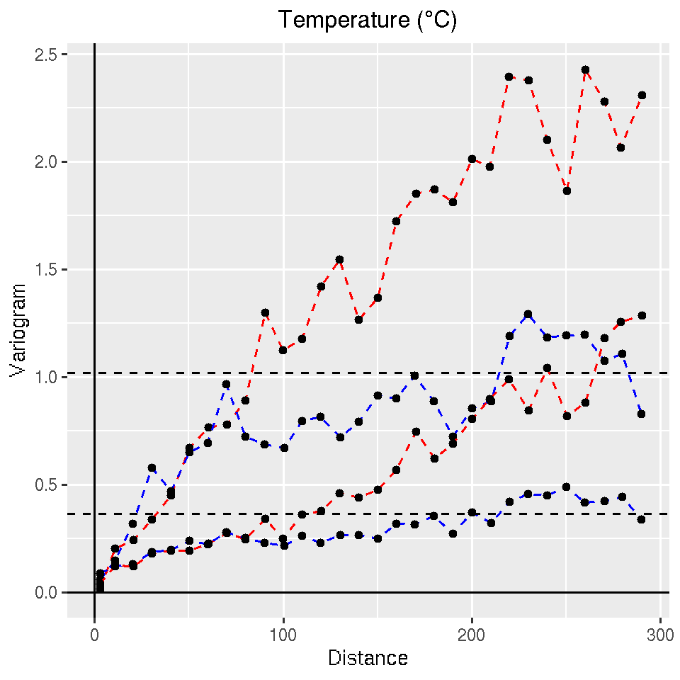

```r
p = ggplot()
p = p + plot.varmod(vario_raw2dir, vario_linetype="dotted")
p = p + plot.varmod(varioKED, vario_linetype="dashed")
p = p + plot.decoration(title="Temperature (°C)")
ggPrint(p)
```

Finally, we fit our model with external drift using the `fit` method (which we call on the experimental variogram of residuals).

```r
err = EDmodel$fit(varioKED,
                   types=ECov_fromKeys(c("NUGGET","CUBIC","GAUSSIAN")))
```

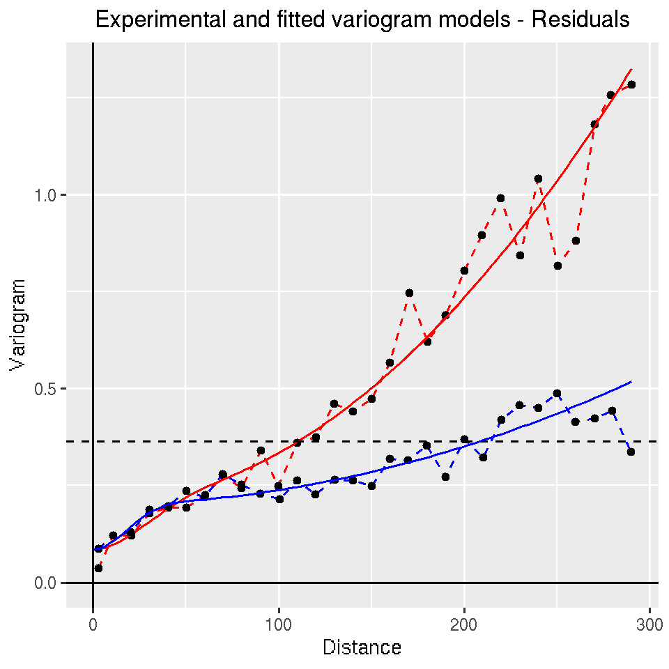

```r
p = ggplot()
p = p + plot.varmod(varioKED, EDmodel)
p = p + plot.decoration(title="Experimental and fitted variogram models - Residuals")
ggPrint(p)
```

#### Kriging with external drifts

Similarly to Universal kriging, to perform a cross-validation or predictions using kriging with External Drifts, we simply call the `xvalid` and `kriging` functions with models where external drifts are specified.

For instance, to compute kriging predictions with external drift of the temperature on the `target`.

```r
err = kriging(dbin=dat, dbout=target, model=EDmodel,
              neigh=uniqueNeigh,
              namconv=NamingConvention_create(prefix="KED"))
```

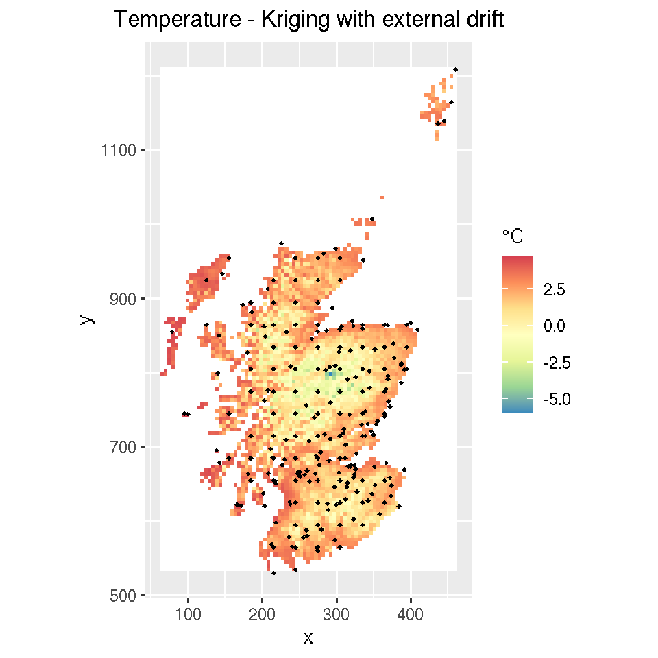

```r
p = ggDefaultGeographic()
p = p + plot.grid(target,name_raster = "KED*estim",
                  show.legend.raster = TRUE, palette="Spectral",legend.name.raster="°C")
p = p + plot.point(dat,flagCst = T,pch=18,cex=1)
p = p + plot.decoration(title="Temperature - Kriging with external drift")
ggPrint(p)
```

For this predictor, we get the following statistics:

```r
opers=EStatOption_fromKeys(c("NUM","MINI","MAXI","MEAN","STDV"))
dbStatisticsPrint(target, names=(c("KED.T*")), opers=opers,
                  title="Statistics on the Kriging with External Drift predictions",
                  radix="")
```

```
##
## Statistics on the Kriging with External Drift predictions
## ---------------------------------------------------------
##                           Number    Minimum    Maximum       Mean   St. Dev.
## KED.Temperature.estim       3092     -6.004      4.773      1.778      1.540
## KED.Temperature.stdev       3092      0.312      0.615      0.396      0.051
```

We can then compare these predictions to the ones obtained by ordinary kriging. We create a correlation plot between the ordinary kriging predictions, and the kriging with external drift (KED) predictions.

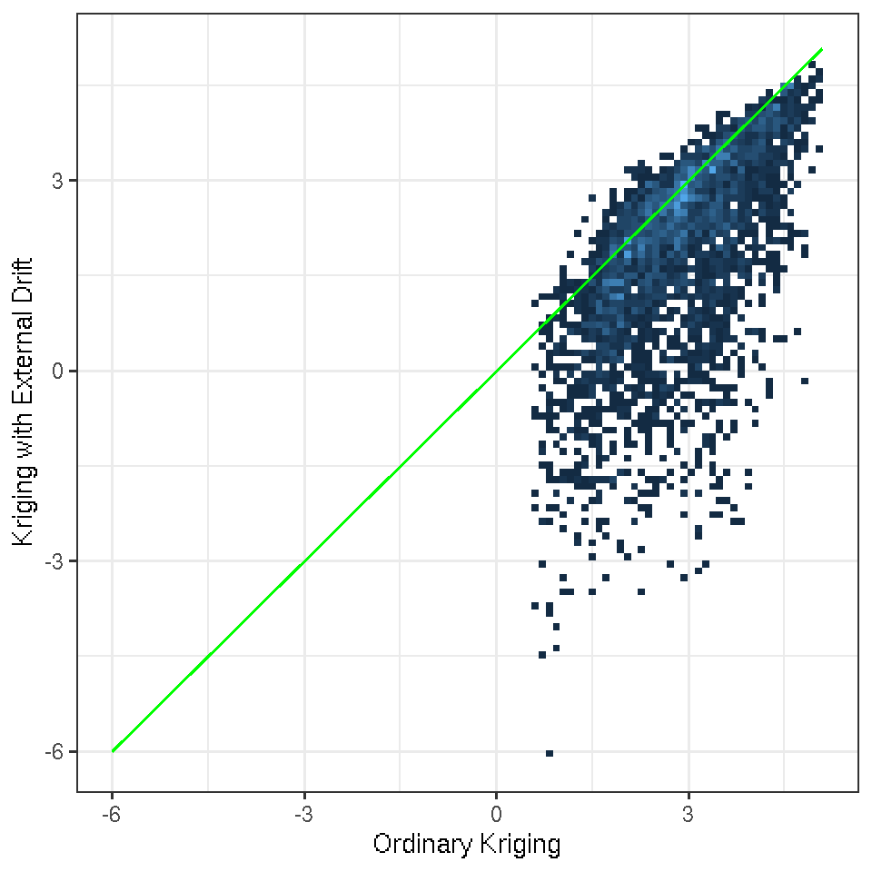

```r
p = ggplot()
p = p + plot.correlation(target, namex="OK.T*estim", namey="KED.T*estim",
                         flagBiss=TRUE,  bins=100)
p = p + plot.decoration(xlab="Ordinary Kriging", ylab="Kriging with External Drift")
ggPrint(p)
```

Note that negative Estimates are present when using External Drift.

#### Cross-validation

To perform a cross-validation, we simply call the `xvalid` function.

```r
err = xvalid(dat, model=EDmodel,
             neigh=uniqueNeigh,
             namconv=NamingConvention_create(prefix="CV_KED",flag_locator=FALSE))
```

The Mean Squared cross-validation and standardized errors of the resulting kriging predictor are:

```r
mse=mean(dat$getColumn("CV_KED*esterr*")^2,na.rm=TRUE)
cat(c("Mean squared cross-validation error:",
        round(mse,3),
      "\n"))
```

```
## Mean squared cross-validation error: 0.172
```

```r
mse=mean(dat$getColumn("CV_KED*stderr*")^2,na.rm=TRUE)
cat(c("Mean squared standardized error:",
        round(mse,3),
      "\n"))
```

```
## Mean squared standardized error: 1.143
```

## Comparing the various kriging predictions

We compare the Mean Squared cross-validation errors obtained in for the different kriging predictions (UK=Universal kriging, OK=Ordinary kriging, COK= Cokriging, KED= Kriging with external drift, KR=Kriging of residuals).

```r
opers=EStatOption_fromKeys(c("NUM","MINI","MAXI","MEAN","STDV"))
dbStatisticsPrint(dat, names=(c("CV*.Temperature.esterr")), opers=opers,
                  title="Mean-squared cross-validation errors",
                  radix="")
```

```
##
## Mean-squared cross-validation errors
## ------------------------------------
##                               Number    Minimum    Maximum       Mean   St. Dev.
## CV_OK.Temperature.esterr         151     -1.354      1.508     -0.012      0.504
## CV_COK.Temperature.esterr        151     -1.759      1.648     -0.105      0.517
## CV_UK.Temperature.esterr         151     -1.713      1.477     -0.003      0.501
## CV_KED.Temperature.esterr        151     -1.577      1.001     -0.009      0.414
```

We then compare various statistics computed for each predictor.

```r
opers=EStatOption_fromKeys(c("NUM","MINI","MAXI","MEAN","STDV"))
dbStatisticsPrint(target, names = (c("*.Temperature.estim")), opers=opers,
                  title="Statistics of the predictors",
                  radix="")
```

```
##
## Statistics of the predictors
## ----------------------------
##                                  Number    Minimum    Maximum       Mean   St. Dev.
## OK.Temperature.estim               3092      0.604      5.083      2.834      0.954
## COK.Temperature.estim              3092      0.200      5.094      2.671      0.970
## ROK.RegRes.Temperature.estim       3092     -0.771      1.586      0.019      0.455
## KR.Temperature.estim               3092     -8.097      5.108      1.445      1.906
## UK.Temperature.estim               3092      0.613      5.051      2.841      0.923
## KED.Temperature.estim              3092     -6.004      4.773      1.778      1.540
```

Finally, we compare various statistics computed for the standard-deviation of each predictor.

```r
opers=EStatOption_fromKeys(c("NUM","MINI","MAXI","MEAN","STDV"))
dbStatisticsPrint(target, names = (c("*.Temperature.stdev")), opers=opers,
                  title="Statistics of the standard-deviation of each predictors",
                  radix="")
```

```
##
## Statistics of the standard-deviation of each predictors
## -------------------------------------------------------
##                                  Number    Minimum    Maximum       Mean   St. Dev.
## OK.Temperature.stdev               3092      0.077      0.992      0.492      0.145
## COK.Temperature.stdev              3092      0.231      0.948      0.448      0.109
## ROK.RegRes.Temperature.stdev       3092      0.304      0.504      0.362      0.031
## UK.Temperature.stdev               3092      0.083      0.919      0.555      0.138
## KED.Temperature.stdev              3092      0.312      0.615      0.396      0.051
```